# Replication Codes for `Does AI help humans make better decisions?`

Sooahn Shin

```r
library(aihuman)
library(tidyr)
library(dplyr)
library(ggplot2)
## set default ggplot theme
theme_set(theme_bw(base_size = 15) + theme(plot.title = element_text(hjust = 0.5)))
```

Ben-Michael, Eli, D. James Greiner, Melody Huang, Kosuke Imai, Zhichao Jiang, and Sooahn Shin. [“Does AI help humans make better decisions?: A statistical evaluation framework for experimental and observational studies”](https://arxiv.org/pdf/2403.12108), 2024.

The data used for this paper, and made available here, are interim, based on only half of the observations in the study and (for those observations) only half of the study follow-up period. We use them only to illustrate methods, not to draw substantive conclusions.

## Overview

In this vignette, we will use the data originally from [Imai, Jiang, Greiner, Halen, and Shin (2023)](https://doi.org/10.1093/jrsssa/qnad010). The essential part of the data is:

- `Z`: A binary treatment $Z_i \in \{0,1\}$ (e.g. PSA provision)
- `D`: A binary decision $D_i \in \{0,1\}$ (e.g. judge’s release decision)
- `A`: A binary AI recommendation $A_i \in \{0,1\}$ (e.g. dichotomized pretrial public safety assessment scores)
- `Y`: A binary outcome $Y_i \in \{0,1\}$ (e.g. new criminal activity)
- Pre-treatment covariates $X_i$ (optional)

The analysis can be conducted based on the following workflow:

1. Data preparation and descriptive analysis
2. Human+AI v. Human comparison
3. AI v. Human comparison
4. Different loss functions
5. Policy Learning

## Data Preparation & Descriptive Analysis

We will be using the following data:

```r
# randomized PSA provision (0: none, 1: provided)
Z <- aihuman::NCAdata$Z
# judge's release decision (0: signature, 1: cash)
D <- if_else(aihuman::NCAdata$D == 0, 0, 1)
# dichotomized pretrial public safety assessment scores (0: signature, 1: cash)
A <- aihuman::PSAdata$DMF
# new criminal activity (0: no, 1: yes)
Y <- aihuman::NCAdata$Y
```

For subgroup analysis, we will use the following covariates:

```r
# race
race_vec <- aihuman::NCAdata |>
  mutate(race = if_else(White == 1, "White", "Non-white")) |>
  pull(race)
# gender
gender_vec <- aihuman::NCAdata |>
  mutate(gender = if_else(Sex == 1, "Male", "Female")) |>
  pull(gender)
```

### Nuisance functions

In the paper, we use doubly robust estimators throughout the analysis. For this purpose, we will be fitting the nuisance functions using the following covariates ($X_i$):

```r
cov_mat <- aihuman::NCAdata |>
  select(-c(Y, D, Z)) |>
  bind_cols(FTAScore = aihuman::PSAdata$FTAScore,
            NCAScore = aihuman::PSAdata$NCAScore,
            NVCAFlag = aihuman::PSAdata$NVCAFlag) |>
  as.matrix()
colnames(cov_mat)
```

```
#>  [1] "Sex"                             "White"
#>  [3] "SexWhite"                        "Age"
#>  [5] "PendingChargeAtTimeOfOffense"    "NCorNonViolentMisdemeanorCharge"
#>  [7] "ViolentMisdemeanorCharge"        "ViolentFelonyCharge"
#>  [9] "NonViolentFelonyCharge"          "PriorMisdemeanorConviction"
#> [11] "PriorFelonyConviction"           "PriorViolentConviction"
#> [13] "PriorSentenceToIncarceration"    "PriorFTAInPast2Years"
#> [15] "PriorFTAOlderThan2Years"         "Staff_ReleaseRecommendation"
#> [17] "FTAScore"                        "NCAScore"
#> [19] "NVCAFlag"
```

Then, the first set of the nuisance functions can be computed as follows, based on the Generalized Boosted Regression Modeling (see `gbm::gbm` function):

```r
nuis_func <- compute_nuisance_functions(Y = Y, D = D, Z = Z, V = cov_mat, shrinkage = 0.01, n.trees = 1000)
```

This gives us the following nuisance functions:

- The decision model $m^{D}(z, x) := \Pr(D = 1 \mid Z = z, X = x)$, for each treatment group $z \in \{0,1\}$. `nuis_func$z_models$d_pred` gives estimated $\hat{m}^{D}(z, X_i)$.
- The outcome model $m^{Y}(z, x) := \Pr(Y = 1 \mid D = 0, Z = z, X = x)$, for each treatment group $z \in \{0,1\}$. `nuis_func$z_models$y_pred` gives estimated $\hat{m}^{Y}(z, X_i)$.
- The propensity score model $e(z, X_i) := \Pr(Z = z \mid X = X_i)$. `nuis_func$pscore` gives estimated $\hat{e}(1, X_i)$.

The second set of the nuisance functions *conditioning on AI recommendation* can be computed similarly:

```r
nuis_func_ai <- compute_nuisance_functions_ai(Y = Y, D = D, Z = Z, A = A, V = cov_mat, shrinkage = 0.01, n.trees = 1000)
```

This gives us the following nuisance functions:

- The decision model $m^{D}(z, a, x) := \Pr(D = 1 \mid Z = z, A = a, X = x)$, for each treatment group $z \in \{0,1\}$ and AI recommendation $a \in \{0,1\}$. `nuis_func_ai$z_models$d_pred` gives estimated $\hat{m}^{D}(z, a, X_i)$.
- The outcome model $m^{Y}(z, a, x) := \Pr(Y = 1 \mid D = 0, Z = z, A = a, X = x)$, for each treatment group $z \in \{0,1\}$ and AI recommendation $a \in \{0,1\}$. `nuis_func_ai$z_models$y_pred` gives estimated $\hat{m}^{Y}(z, a, X_i)$.
- The propensity score model $e(z, X_i) := \Pr(Z = z \mid X = X_i)$. `nuis_func_ai$pscore` gives estimated $\hat{e}(1, X_i)$.

For the reproducibility, we will be using the pre-computed nuisance functions, generated from the same codes above.

### Contingency table of human decisions and PSA recommendations

Comparison between human decisions and PSA-generated recommendations are summarized in the following contingency table (Table 1 in the paper).

```r
counts <- table(D[Z == 0], A[Z == 0])
proportions <- prop.table(counts) * 100
combined_table_human <- matrix(sprintf("%.1f%% (%d)", proportions, counts),
                         nrow = nrow(counts), ncol = ncol(counts))
colnames(combined_table_human) <- c("Signature", "Cash")
rownames(combined_table_human) <- c("Signature", "Cash")
knitr::kable(combined_table_human, caption = "Table 1 (Human v. PSA)")
```

Table 1 (Human v. PSA)

|  | Signature | Cash |
| --- | --- | --- |
| Signature | 54.1% (510) | 20.7% (195) |
| Cash | 9.4% (89) | 15.8% (149) |

```r
counts <- table(D[Z == 1], A[Z == 1])
proportions <- prop.table(counts) * 100
combined_table_human_ai <- matrix(sprintf("%.1f%% (%d)", proportions, counts),
                         nrow = nrow(counts), ncol = ncol(counts))
colnames(combined_table_human_ai) <- c("Signature", "Cash")
rownames(combined_table_human_ai) <- c("Signature", "Cash")
knitr::kable(combined_table_human_ai, caption = "Table 1 (Human+PSA v. PSA)")
```

Table 1 (Human+PSA v. PSA)

|  | Signature | Cash |
| --- | --- | --- |
| Signature | 57.3% (543) | 17.1% (162) |
| Cash | 7.4% (70) | 18.2% (173) |

### Agreement between human decisions and PSA recommendations

We can analyze the impact of AI recommendations on agreement between human decisions and AI recommendations using the difference in means estimates of an indicator $1\{D_i = A_i\}$. The results are as follows (Figure S1 in the appendix).

```r
table_agreement(
  Y = Y,
  D = D,
  Z = Z,
  A = A,
  subgroup1 = race_vec,
  subgroup2 = gender_vec,
  label.subgroup1 = "Race",
  label.subgroup2 = "Gender"
) |>
  mutate_at(vars(agree_diff, agree_diff_se, ci_ub, ci_lb), ~round(., 3)) |>
  knitr::kable(caption = "Agreement of Human and PSA Decision Makers")
```

Agreement of Human and PSA Decision Makers

| cov | X | agree_diff | agree_diff_se | ci_ub | ci_lb |
| --- | --- | --- | --- | --- | --- |
| Overall | Overall | 0.056 | 0.020 | 0.097 | 0.016 |
| Race | Non-white | 0.030 | 0.031 | 0.090 | -0.031 |
| Race | White | 0.079 | 0.027 | 0.132 | 0.026 |
| Gender | Female | 0.025 | 0.044 | 0.111 | -0.060 |
| Gender | Male | 0.065 | 0.023 | 0.110 | 0.019 |

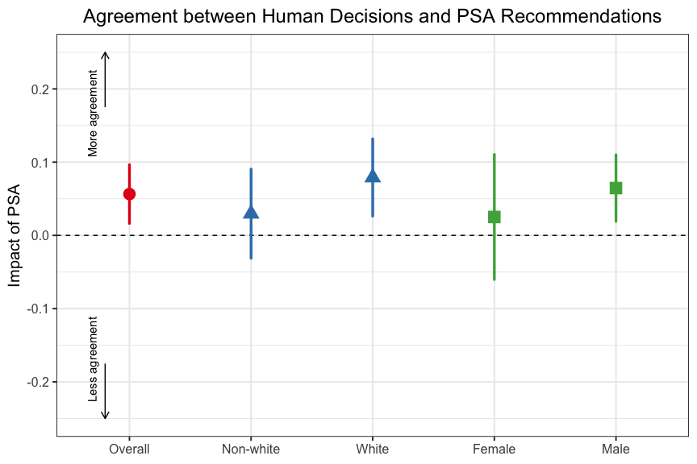

```r
plot_agreement(
  Y = Y,
  D = D,
  Z = Z,
  A = A,
  subgroup1 = race_vec,
  subgroup2 = gender_vec,
  label.subgroup1 = "Race",
  label.subgroup2 = "Gender",
  x.order = c("Overall", "Non-white", "White", "Female", "Male"),
  p.title = "Agreement between Human Decisions and PSA Recommendations", p.lb = -0.25, p.ub = 0.25
)
```

## Human+AI v. Human comparison

We now compare difference in risk between human+AI and human decision makers using AIPW estimators. You may choose between (1) AIPW estimator and (2) difference-in-means (Neyman) estimator. You can also specify the loss ratio between false positives and false negatives using `l01` parameter. For the subgroup analysis, you can specify the subgroup variable using `X`.

```r
# AIPW estimator
compute_stats_aipw(
  Y = Y,
  D = D,
  Z = Z,
  nuis_funcs = nuis_func,
  true.pscore = rep(0.5, length(D)),
  X = NULL,
  l01 = 1
)
```

```
#> # A tibble: 1 × 8
#>   Z_focal Z_compare loss_diff loss_diff_se fn_diff fn_diff_se fp_diff fp_diff_se
#>     <dbl>     <dbl>     <dbl>        <dbl>   <dbl>      <dbl>   <dbl>      <dbl>
#> 1       1         0    0.0419       0.0359  0.0177     0.0184  0.0242     0.0218
```

```r
# Difference-in-means (Neyman) estimator
compute_stats(
  Y = Y,
  D = D,
  Z = Z,
  X = NULL,
  l01 = 1
)
```

```
#> # A tibble: 1 × 8
#>   Z_focal Z_compare loss_diff loss_diff_se fn_diff fn_diff_se fp_diff fp_diff_se
#>     <dbl>     <dbl>     <dbl>        <dbl>   <dbl>      <dbl>   <dbl>      <dbl>
#> 1       1         0    0.0420       0.0364  0.0190     0.0184  0.0230     0.0229
```

The results can be visualized as follows (Figure 1 in the paper). You may use `plot_diff_human()` function for the Neyman estimator.

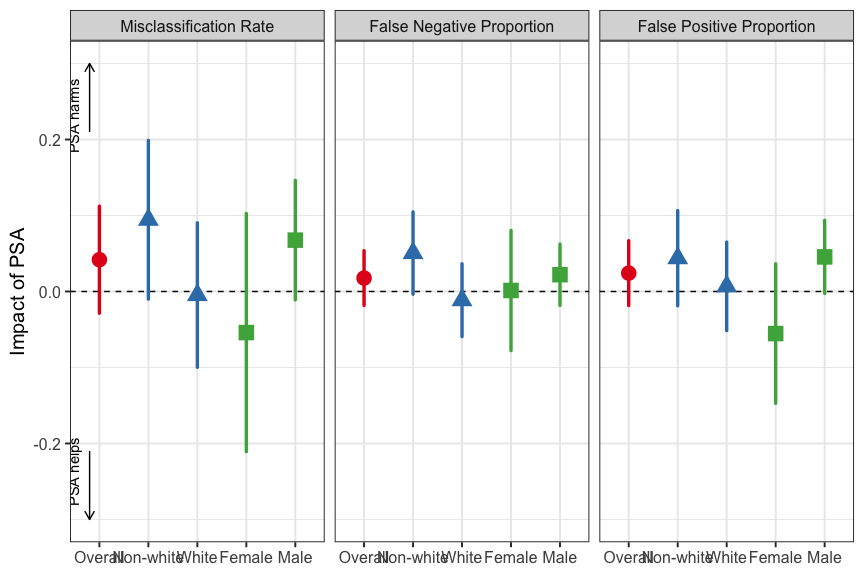

```r
plot_diff_human_aipw(
  Y = Y,
  D = D,
  Z = Z,
  nuis_funcs = nuis_func,
  l01 = 1,
  true.pscore = rep(0.5, length(D)),
  subgroup1 = race_vec,
  subgroup2 = gender_vec,
  label.subgroup1 = "Race",
  label.subgroup2 = "Gender",
  x.order = c("Overall", "Non-white", "White", "Female", "Male"),
  p.title = NULL, p.lb = -0.3, p.ub = 0.3
)
```

### How the human overrides the AI recommendation?

We can answer the question using the following subgroup analysis defined by `A`.

First, subgroup analysis for the cases where AI recommends harsher decision ($A = 1$). The figure shows how the human overrides the AI recommendation in terms of true negative proportion (TNP), false negative proportion (FNP), and their differences (Figure S2 in the appendix).

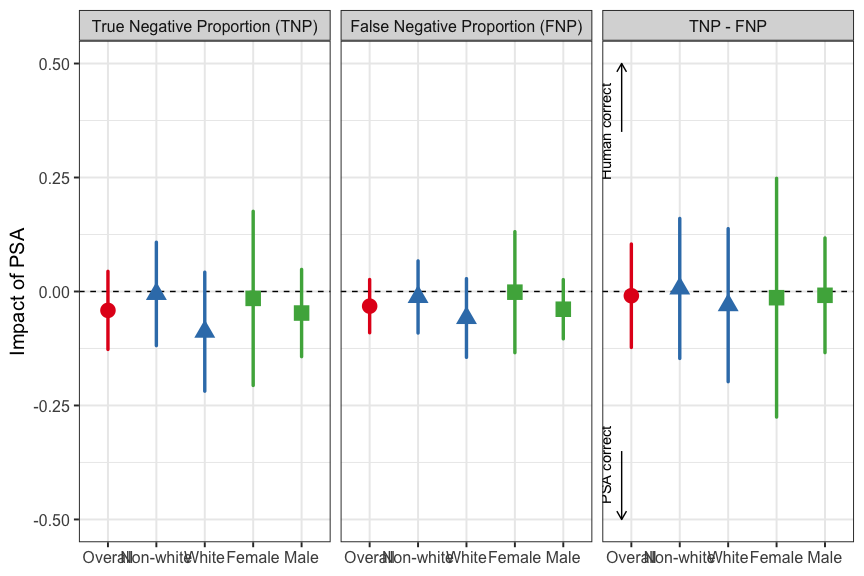

```r
plot_diff_subgroup(
  Y = Y,
  D = D,
  Z = Z,
  A = A,
  a = 1,
  l01 = 1,
  nuis_funcs = nuis_func,
  true.pscore = rep(0.5, length(D)),
  subgroup1 = race_vec,
  subgroup2 = gender_vec,
  label.subgroup1 = "Race",
  label.subgroup2 = "Gender",
  x.order = c("Overall", "Non-white", "White", "Female", "Male"),
  p.title = NULL, p.lb = -0.5, p.ub = 0.5,
  label = "TNP - FNP",
  metrics = c("True Negative Proportion (TNP)", "False Negative Proportion (FNP)", "TNP - FNP")
)
```

Second, subgroup analysis for the cases where AI recommends lenient decision ($A = 0$) is also available. The figure shows how human overrides the AI recommendation in terms of true positive proportion (TPP), false positive proportion (FPP), and their differences (Figure S3 in the appendix).

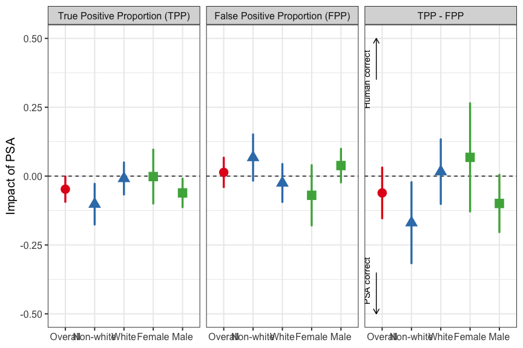

```r
plot_diff_subgroup(
  Y = Y,
  D = D,
  Z = Z,
  A = A,
  a = 0,
  l01 = 1,
  nuis_funcs = nuis_func,
  true.pscore = rep(0.5, length(D)),
  subgroup1 = race_vec,
  subgroup2 = gender_vec,
  label.subgroup1 = "Race",
  label.subgroup2 = "Gender",
  x.order = c("Overall", "Non-white", "White", "Female", "Male"),
  p.title = NULL, p.lb = -0.5, p.ub = 0.5,
  label = "TPP - FPP",
  metrics = c("True Positive Proportion (TPP)", "False Positive Proportion (FPP)", "TPP - FPP")
)
```

## AI v. Human comparison

We now compare difference in risk between AI and human decision makers using AIPW estimators. Note that these quantities are partially identified given the assumptions made in the paper.

```r
# AIPW estimator
compute_bounds_aipw(
  Y = Y,
  D = D,
  Z = Z,
  A = A,
  nuis_funcs = nuis_func,
  nuis_funcs_ai = nuis_func_ai,
  true.pscore = rep(0.5, length(D)),
  X = NULL,
  l01 = 1
)
```

```
#> # A tibble: 2 × 14
#>   Z_focal Z_compare fn_diff_lb fn_diff_ub fp_diff_lb fp_diff_ub loss_diff_lb
#>   <chr>   <chr>          <dbl>      <dbl>      <dbl>      <dbl>        <dbl>
#> 1 AI      1            -0.0578    0.00203     0.0421      0.102      -0.0156
#> 2 AI      0            -0.0401    0.0197      0.0674      0.127       0.0273
#> # ℹ 7 more variables: loss_diff_ub <dbl>, fn_diff_lb_se <dbl>,
#> #   fn_diff_ub_se <dbl>, fp_diff_lb_se <dbl>, fp_diff_ub_se <dbl>,
#> #   loss_diff_lb_se <dbl>, loss_diff_ub_se <dbl>
```

The results can be visualized as follows (Figure 2 and Figure S4 in the paper).

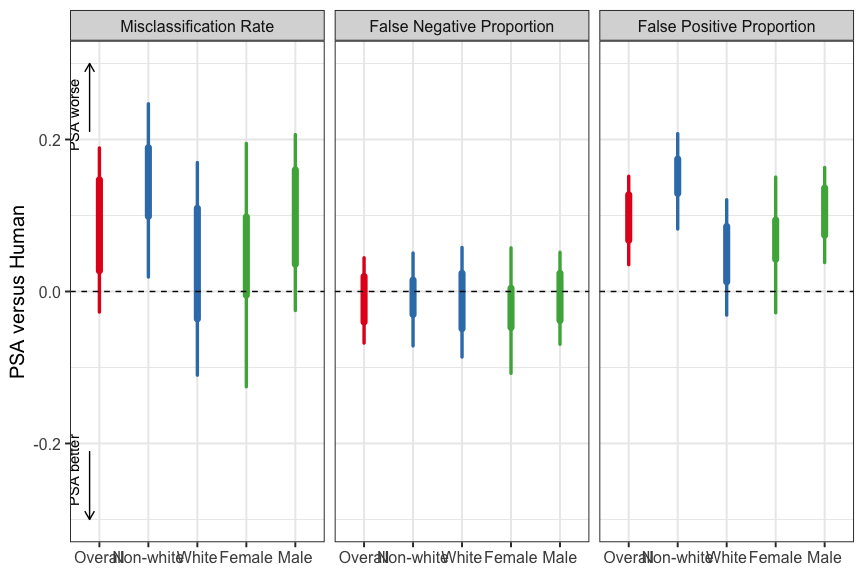

```r
# AI versus Human
plot_diff_ai_aipw(
  Y = Y,
  D = D,
  Z = Z,
  A = A,
  z_compare = 0,
  nuis_funcs = nuis_func,
  nuis_funcs_ai = nuis_func_ai,
  l01 = 1,
  true.pscore = rep(0.5, length(D)),
  subgroup1 = race_vec,
  subgroup2 = gender_vec,
  label.subgroup1 = "Race",
  label.subgroup2 = "Gender",
  x.order = c("Overall", "Non-white", "White", "Female", "Male"),
  p.title = NULL, p.lb = -0.3, p.ub = 0.3
)
```

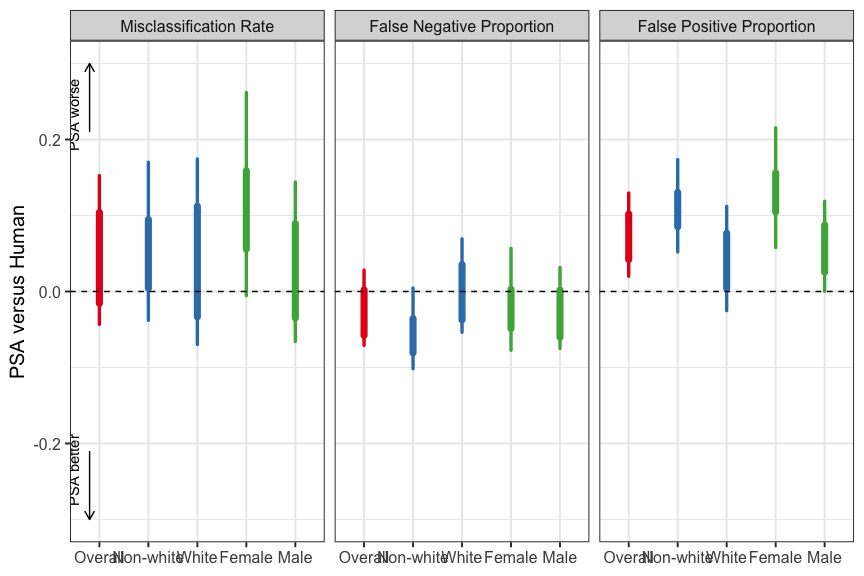

```r
# AI versus Human+AI
plot_diff_ai_aipw(
  Y = Y,
  D = D,
  Z = Z,
  A = A,
  z_compare = 1,
  nuis_funcs = nuis_func,
  nuis_funcs_ai = nuis_func_ai,
  l01 = 1,
  true.pscore = rep(0.5, length(D)),
  subgroup1 = race_vec,
  subgroup2 = gender_vec,
  label.subgroup1 = "Race",
  label.subgroup2 = "Gender",
  x.order = c("Overall", "Non-white", "White", "Female", "Male"),
  p.title = NULL, p.lb = -0.3, p.ub = 0.3
)
```

### Alternative AI Recommendations

Note that researcher can specify different AI recommendations by changing the `A` variable. For example, in the paper, we have used Llama3 recommendations as an alternative comparison.

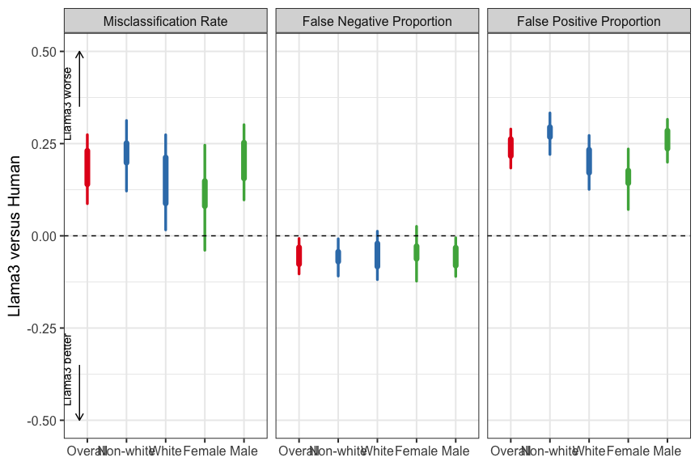

```r
# Llama3 versus Human
plot_diff_ai_aipw(
  Y = Y,
  D = D,
  Z = Z,
  A = A_llama,
  z_compare = 0,
  nuis_funcs = nuis_func,
  nuis_funcs_ai = nuis_func_ai,
  l01 = 1,
  true.pscore = rep(0.5, length(D)),
  subgroup1 = race_vec,
  subgroup2 = gender_vec,
  label.subgroup1 = "Race",
  label.subgroup2 = "Gender",
  x.order = c("Overall", "Non-white", "White", "Female", "Male"),
  y.lab = "Llama3 versus Human", p.label = c("Llama3 worse", "Llama3 better"),
  p.title = NULL, p.lb = -0.5, p.ub = 0.5
)
```

## Different loss functions

As noted earlier, one may specify different loss functions by changing the `l01` parameter. Here, we provide an example of when human decision maker is preferred over AI recommendation (Figure 3 and Figure S5 in the paper).

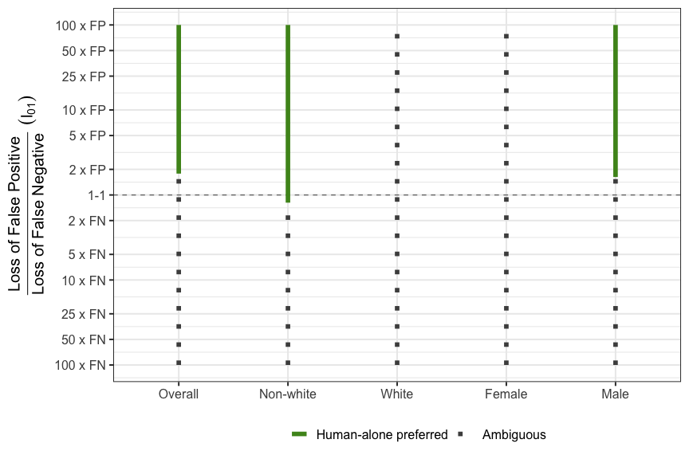

```r
# When to prefer human decision maker over AI recommendation
plot_preference(
  Y = Y,
  D = D,
  Z = Z,
  A = A,
  z_compare = 0,
  nuis_funcs = nuis_func,
  nuis_funcs_ai = nuis_func_ai,
  l01_seq = 10^seq(-2, 2, length.out = 200),
  alpha = 0.05,
  true.pscore = rep(0.5, length(D)),
  subgroup1 = race_vec,
  subgroup2 = gender_vec,
  label.subgroup1 = "Race",
  label.subgroup2 = "Gender",
  x.order = c("Overall", "Non-white", "White", "Female", "Male"),
  p.title = NULL,
  legend.position = "bottom",
  p.label = c("AI-alone preferred", "Human-alone preferred", "Ambiguous")
) +
  scale_color_manual("",
                     values = c("", "#4d9221", "grey30"),
                     labels = c("", "Human-alone preferred", "Ambiguous"), drop = FALSE
  ) +
  scale_linetype_manual("", values = c(1, 1, 3), labels = c("", "Human-alone preferred", "Ambiguous"), drop = FALSE)
```

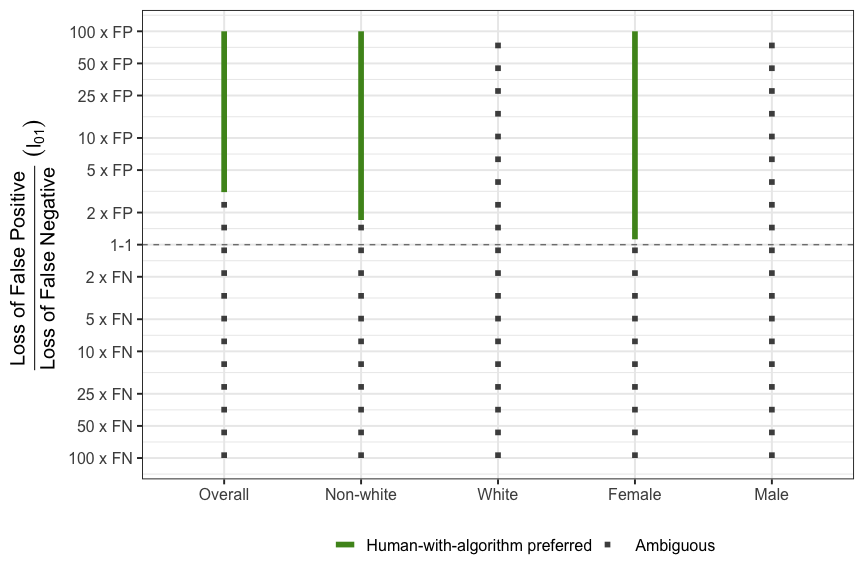

```r
# When to prefer human+AI decision maker over AI recommendation
plot_preference(
  Y = Y,
  D = D,
  Z = Z,
  A = A,
  z_compare = 1,
  nuis_funcs = nuis_func,
  nuis_funcs_ai = nuis_func_ai,
  l01_seq = 10^seq(-2, 2, length.out = 200),
  alpha = 0.05,
  true.pscore = rep(0.5, length(D)),
  subgroup1 = race_vec,
  subgroup2 = gender_vec,
  label.subgroup1 = "Race",
  label.subgroup2 = "Gender",
  x.order = c("Overall", "Non-white", "White", "Female", "Male"),
  p.title = NULL,
  legend.position = "bottom",
  p.label = c("AI-alone preferred", "Human-alone preferred", "Ambiguous")
) +
  scale_color_manual("",
              values = c("", "#4d9221", "grey30"),
              labels = c("", "Human-with-algorithm preferred", "Ambiguous"), drop = FALSE
          ) +
  scale_linetype_manual("", values = c(1, 1, 3), labels = c("", "Human-with-algorithm preferred", "Ambiguous"), drop = FALSE)
```

## Policy Learning

Finally, we can conduct policy learning using the following codes. The optimization requires `gurobi` software, and you may need to install it separately ([documentation](https://docs.gurobi.com/)). In this vignette, we provide the codes for replicating the results in the paper (Figure 4 and Table 3).

### Helper functions

```r
library(gurobi)
## Optimization functions
make_edge_mat <- function(X) {
  n <- nrow(X)
  lapply(1:n,
         function(i) {
           vapply(1:n,
                  function(j) {
                    if(all(X[i,] <= X[j,]) & i != j) {
                      e <- numeric(2 * n)
                      e[j] <- 1
                      e[n + i] <- -1
                    } else {
                      e <- numeric(2 * n)
                    }
                    return(e)
                  },
                  numeric(2 * n)) %>% t()
         }) %>% do.call(rbind, .) %>% unique() %>% Matrix::Matrix()
}

make_action_mat <- function(n, k) {
  do.call(cbind, lapply(1:k, function(a) a * Matrix::Diagonal(n)))
}

create_monotone_constraints <- function(X, rev = FALSE) {
  n <- nrow(X)
  d <- ncol(X)

  # policy vector is (pi(1,.),...,pi(A,.))
  # sum to one constraints
  pi_sum_to_one <- do.call(cbind, lapply(1:2, function(x) Matrix::Diagonal(n)))
  rhs_sum_to_one <- rep(1, n)
  sense_sum_to_one <- rep("=", n)

  # monotonicy constraints
  edge_mat <- make_edge_mat(X)
  action_mat <- make_action_mat(n, 2)
  # the following codes insure that (1) edge_mat: select pairs that monotonicity should hold in a correct order (i.e. if X[i,]<X[j,] then assign 1 to j and -1 to i) (2) rbind(action_mat, action_mat): if multiplied by a vector of binary actions (length = 2*n since there exist two actions), it selects the action that has been chosen (e.g. if action 1 = 0 and action 2 = 1 for a given observation, it gives the value of 2)
  monotone_mat <- edge_mat %*% rbind(action_mat, action_mat)
  rhs_monotone <- rep(0, nrow(monotone_mat))
  if(isTRUE(rev)) {
    sense_monotone <- rep("<=", nrow(monotone_mat))
  } else {
    sense_monotone <- rep(">=", nrow(monotone_mat))
  }
  A <- rbind(pi_sum_to_one, monotone_mat)
  rhs <- c(rhs_sum_to_one, rhs_monotone)
  sense <- c(sense_sum_to_one, sense_monotone)

  # restrict variables
  vtype <- rep("B", n * 2) # binary policy decisions

  return(list(A = A, rhs = rhs, sense = sense, vtype = vtype))
}

get_monotone_policy <- function(X, wts, rev = FALSE) {
  n <- nrow(X)
  # get the constraints
  model <- create_monotone_constraints(as.matrix(X), rev = rev)
  # solve
  model$obj <- c(numeric(n), wts)
  model$modelsense <- "min"
  sol <- gurobi(model)

  # extract values
  policy <- apply(matrix(sol$x, ncol = 2), 1, which.max) - 1

  return(policy)
}

get_monotone_policy_ai <- function(X, wts, rev = FALSE) {
  X_df <- data.frame(X)
  wts_df <- data.frame(wts)
  colnames(wts_df) <- "wts"
  comb_df <- bind_cols(X_df, wts_df)

  # get distinct X values and the sum of the weights on them
  grouped_df <- comb_df %>%
    group_by(across(-wts)) %>%
    summarise(across(everything(), sum),
              n = n(),
              .groups = "drop"
    )

  X_distinct <- grouped_df %>%
    select(-wts, -n) %>%
    as.matrix()
  wts_distinct <- grouped_df %>% pull(wts)

  policy <- get_monotone_policy(X_distinct, wts_distinct, rev = rev)

  grouped_df <- grouped_df %>%
    mutate(policy = policy)

  return(grouped_df)
}

## Weights functions
compute_wts_dr <- function(Y, D, Z, nuis_funcs, pscore = NULL, l01 = 1) {
  ## update the propensity score if provided
  if (!is.null(pscore)) {
    nuis_funcs$pscore <- pscore
  }

  ## check whether Z is 0/1 binary variable
  if (any(sort(unique(Z)) != c(0, 1))) {
    stop("Z must be a binary variable")
  }
  dat <- data.frame(Y = Y, D = D, Z = Z, pscore = nuis_funcs$pscore)

  preds <- nuis_funcs$z_models |>
    pivot_wider(names_from = c(Z), values_from = c(-Z, -idx), names_sep = "") |>
    select(-idx)

  dat <- dat %>%
    bind_cols(preds)

  wts <- dat %>%
    mutate(
      p.1i = (1 - d_pred1) * ((1 + l01) * y_pred1 - l01) + (1 + l01) * Z * (1 - D) * (Y - y_pred1) / pscore - ((1 + l01) * y_pred1 - l01) * Z * (D - d_pred1) / pscore,
      p.0i = (1 - d_pred0) * ((1 + l01) * y_pred0 - l01) + (1 + l01) * (1 - Z) * (1 - D) * (Y - y_pred0) / (1 - pscore) - ((1 + l01) * y_pred0 - l01) * (1 - Z) * (D - d_pred0) / (1 - pscore),
      p.i = p.1i - p.0i
    ) %>%
    pull(p.i)

  return(wts)
}

compute_bound_wts_dr <- function(Y, A, D, Z, nuis_funcs1, nuis_funcs2, pscore = NULL, l01 = 1) {
  ## update the propensity score if provided
  if (!is.null(pscore)) {
    nuis_funcs1$pscore <- pscore
    nuis_funcs2$pscore <- pscore
  }

  ## check whether Z is 0/1 binary variable
  if (any(sort(unique(Z)) != c(0, 1))) {
    stop("Z must be a binary variable")
  }
  data <- data.frame(Y = Y, D = D, Z = Z, A = A, pscore = nuis_funcs1$pscore)

  preds1 <- nuis_funcs1$z_models |>
    pivot_wider(names_from = c(Z), values_from = c(-Z, -idx), names_sep = "") |>
    select(-idx)

  preds2 <- nuis_funcs2$z_models |>
    pivot_wider(names_from = c(Z, A), values_from = c(-Z, -A, -idx), names_sep = "") |>
    select(-idx)

  data <- data %>%
    bind_cols(preds1, preds2)

  wts <- data %>%
    mutate(
      # gU0.i = 1 if z'=1 i.e. Pr(Y=0,D=0|A=0,Z=1,X=x) > Pr(Y=0,D=0|A=0,Z=0,X=x)
      gU0.i = 1 * ((1 - d_pred10) * (1 - y_pred10) >= (1 - d_pred00) * (1 - y_pred00)),
      # phi_z0(x): Pr(Y=0,D=0,A=0|Z=z,X=x)
      p10.i = (1 - A) * (1 - d_pred10) * (1 - y_pred10) - Z * (1 - A) * (1 - D) * (Y - y_pred10) / pscore - (1 - y_pred10) * Z * (1 - A) * (D - d_pred10) / pscore,
      p00.i = (1 - A) * (1 - d_pred00) * (1 - y_pred00) - (1 - Z) * (1 - A) * (1 - D) * (Y - y_pred00) / (1 - pscore) - (1 - y_pred00) * (1 - Z) * (1 - A) * (D - d_pred00) / (1 - pscore)
    ) %>%
    mutate(
      p10_gU0.i = p10.i * gU0.i,
      p00_gU0.i = p00.i * gU0.i
    ) %>%
    mutate(
      fn_diff_ub.0i = p01.i - p0.i + p00.D.i - p10_gU0.i + p00_gU0.i,
      fp_diff_ub.0i = p01.i - p0.i + p01.D.i - p10_gU0.i + p00_gU0.i,
      loss_diff_ub.0i = fn_diff_ub.0i + l01 * fp_diff_ub.0i
    ) %>%
    pull(loss_diff_ub.0i)

  return(wts)
}
```

```r
get_policy_value <- function(policy, n_obs = 1891) {
    v <- policy |>
        mutate(wts_policy = wts * policy) |>
        pull(wts_policy) |>
        sum()
    return(v/n_obs)
}
```

### Whether to provide PSA

Let’s consider policy class with an increasing monotonicity constraint.

```r
psaX <- cov_mat[,c("FTAScore", "NCAScore", "NVCAFlag")]
nca_wts <- compute_wts_dr(Y = Y, D = D, Z = Z, nuis_funcs = nuis_func, pscore = 0.5, l01 = 1)
nca_provide_policy <- get_monotone_policy_ai(X = psaX, wts = nca_wts)
```

```r
## The estimated values of the empirical risk minimization problem
get_policy_value(nca_provide_policy, n_obs = length(Y))
```

```
#> [1] -0.01014338
```

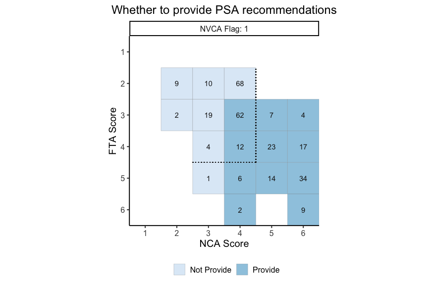

```r
## Visualization
nca_provide_policy |>
    filter(NVCAFlag == 1) |>
    mutate(
            policy = factor(policy, levels = c(0, 1)),
            NVCAFlag = paste0("NVCA Flag: ", NVCAFlag)
        ) |>
        ggplot(aes(x = NCAScore, y = FTAScore, fill = policy)) +
        geom_tile(color = "grey50") +
        geom_segment(aes(x = 2.5, xend = 4.5, y = 4.5, yend = 4.5), lty = 3) +
        geom_segment(aes(x = 4.5, xend = 4.5, y = 4.5, yend = 1.5), lty = 3) +
        facet_grid(. ~ NVCAFlag) +
        scale_fill_brewer("PSA Recommendation Provision",
            type = "seq", palette = "Blues",
            direction = 1
        ) +
        scale_y_reverse(breaks = 1:6) +
        scale_x_continuous(breaks = 1:6) +
        expand_limits(x = 0.5:6, y =0.5:6) +
        labs(x = "NCA Score",
             y = "FTA Score",
             title = "Whether to provide PSA recommendations") +
        coord_fixed(expand = F) +
        theme_classic(base_size = 15) +
        scale_fill_brewer("", breaks = 0:1, labels = c("Not Provide", "Provide")) +
        theme(legend.position = "bottom", plot.title = element_text(hjust = 0.5)) +
        geom_text(aes(label = n), color = "grey10")
```

We can also consider policy class with a decreasing monotonicity constraint.

```r
nca_provide_policy_dec <- get_monotone_policy_ai(X = psaX, wts = nca_wts, rev = TRUE)
```

```r
get_policy_value(nca_provide_policy_dec, n_obs = length(Y))
```

```
#> [1] -0.008533944
```

### Whether to follow PSA

Let’s consider policy class with an increasing monotonicity constraint.

```r
nca_wts <- compute_bound_wts_dr(Y = Y, A = A, D = D, Z = Z, nuis_funcs1 = nuis_func, nuis_funcs2 = nuis_func_ai, pscore = 0.5, l01 = 1)
nca_follow_policy <- get_monotone_policy_ai(X = psaX, wts = nca_wts)
```

```r
## The estimated values of the empirical risk minimization problem
get_policy_value(nca_follow_policy, n_obs = length(Y))
```

```
#> [1] -0.003514698
```

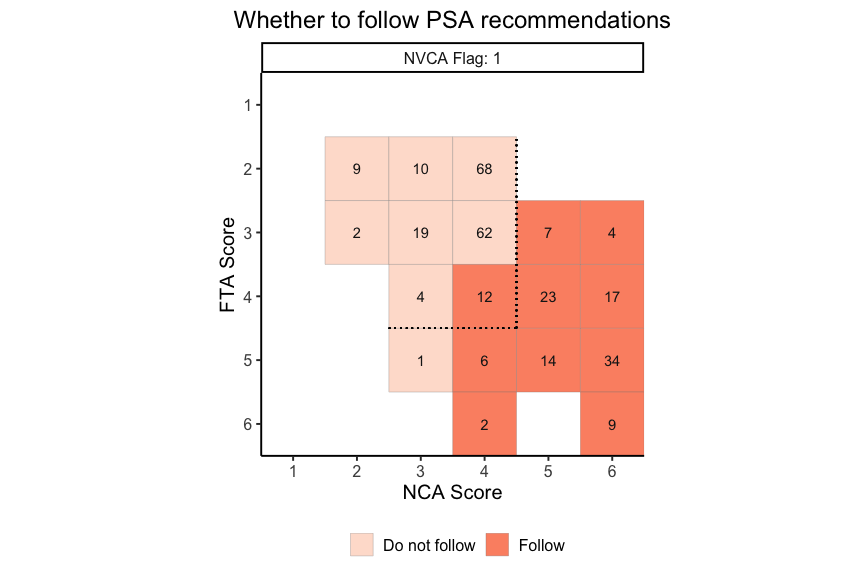

```r
## Visualization
nca_follow_policy |>
    filter(NVCAFlag == 1) |>
    mutate(
            policy = factor(policy, levels = c(0, 1)),
            NVCAFlag = paste0("NVCA Flag: ", NVCAFlag)
        ) |>
        ggplot(aes(x = NCAScore, y = FTAScore, fill = policy)) +
        geom_tile(color = "grey50") +
        geom_segment(aes(x = 2.5, xend = 4.5, y = 4.5, yend = 4.5), lty = 3) +
        geom_segment(aes(x = 4.5, xend = 4.5, y = 4.5, yend = 1.5), lty = 3) +
        facet_grid(. ~ NVCAFlag) +
        scale_fill_brewer("PSA Recommendation Provision",
            type = "seq", palette = "Blues",
            direction = 1
        ) +
        scale_y_reverse(breaks = 1:6) +
        scale_x_continuous(breaks = 1:6) +
        expand_limits(x = 0.5:6, y =0.5:6) +
        labs(x = "NCA Score",
             y = "FTA Score",
             title = "Whether to follow PSA recommendations") +
        coord_fixed(expand = F) +
        theme_classic(base_size = 15) +
        scale_fill_brewer("", type = "seq", palette = "Reds", direction = 1,
                          breaks = 0:1, label = c("Do not follow", "Follow")) +
        theme(legend.position = "bottom", plot.title = element_text(hjust = 0.5)) +
        geom_text(aes(label = n), color = "grey10")
```

We can also consider policy class with a decreasing monotonicity constraint.

```r
nca_follow_policy_dec <- get_monotone_policy_ai(X = psaX, wts = nca_wts, rev = TRUE)
```

```r
get_policy_value(nca_follow_policy_dec, n_obs = length(Y))
```

```
#> [1] 0
```